# Project Proposal

# Proposal Part 1: Members

Lewis Dubrowski, Reed Frellick, Neil Pierre-Louis, Jimmy Slaight

# Proposal Part 2: Description and Location of Data

Our primary data source is the “all teams” NHL hockey dataset available at https://www.moneypuck.com/data.htm. This dataset includes NHL shooting and defensive data for every observation of team, game, and situation (5v5, 4v5, etc) going back to 2008. It includes standard counting and rate statistics as well as many of Money Puck’s own predicted statistics like expected goals. A data dictionary describing all variables is provided on the website at the same link above, and both the dictionary and dataset can be made available on our website at the instructor’s request.

# Proposal Part 3: Motivations and Goals

The motivation of our project is to explore and find statistically sound models and methods that help predict success in the NHL. Specifically we are focusing on a 2 tiered approach to “success;” we are going to seek out ways in which we can best predict goals for and against a team in a given game given counting or rate statistics we predict they will produce in the game or data we have for prior games as one might have during the NHL season, and from these predictions we are going to predict whether or not a team will win a specific game using classification methods. With this basis of win prediction set, we could realistically extrapolate it out and forecast strings of games or even entire seasons to get a snapshot of how successful a team might be not only at scoring goals or winning one game but being a successful team in the standings.

Our hope is to create these models in such a way that they are useful for weighing the importance of certain statistics for team building and strategy or for predicting/betting on games, and while we do not expect them to perfectly predict outcomes we also will seek to produce models that capture as much of the variation in goals and in wins that we can so that they do give an informed prediction stronger than a coin flip.

# Proposal Part 4: EDA

## Basic Data Overview

Before we start analyzing the data, we want to get an idea of what is included. We can do this in three parts: looking at how much data we have per season, per team, and per game.

### Data Per Season

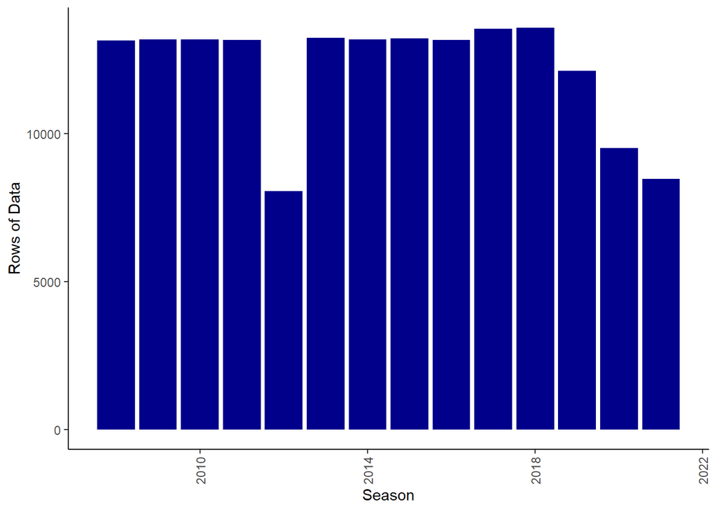

Most seasons have about the same amount of data. One season (2012) has much fewer than the seasons around it in the data. The 2012-2013 NHL season was shortened due to a lockout, and teams only played 48 games that season. This explains the dip in data for the 2012 season. There is also less data for the 2019-20 and 2020-21 seasons. This can likely be explained by COVID-19, which caused game cancellations in both years. Finally, the final season in the dataset, 2021-22 is still ongoing, so there is less data for this season than the others. (Note: moneypuck updates the dataset on its website as games are played, but for the purposes of our project, we will use the dataset as it was on February 28. As a result, our dataset will only contain games played through 2/27/2022).

### Data Per Team

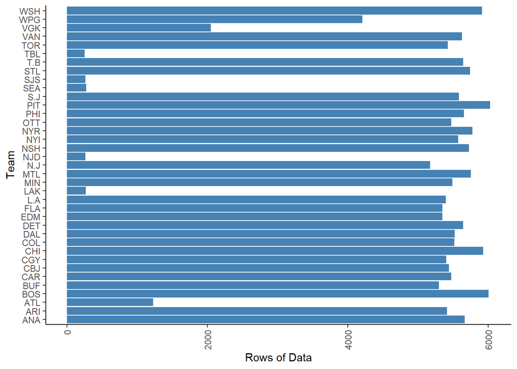

Similar to the data for different seasons, different teams have roughly equal data among them, with some notable exceptions. Some teams have much less data than others in the sample. For some teams, this is because they exist under two different names in the dataset. For instance, TBL is the same as T.B (Tampa Bay Lightning), SJS = S.J (San Jose Sharks), NJD = N.J (New Jersey Devils) and LAK = L.A (Los Angeles Kings). When we do our analysis, we will want to combine the data for these teams so we do not accidentally count them as separate franchises.

For SEA (Seattle Kraken) and VGK (Vegas Golden Knights), the lack of data is explained by the fact that they are expansion teams. VGK was only added to the NHL in the 2017-18 season, while SEA’s first season was 2021-22.

Finally, ATL (Atlanta Thrashers) only existed until the 2010-11 season, when they moved to Winnipeg (WPG). Thus, ATL and WPG are the same franchise.

### Data Per Game

```
## # A tibble: 6 x 2
##       gameId num_rows
##        <dbl>    <int>
## 1 2008020001       10
## 2 2008020002       10
## 3 2008020003       10
## 4 2008020004       10
## 5 2008020005       10
## 6 2008020006       10
```

There are exactly 10 rows of data for each game in the sample (5 for each team). The reason can be explained by the “situation” variable:

```
## # A tibble: 10 x 3
## # Groups:   gameId [2]
##        gameId situation num_rows
##         <dbl> <chr>        <int>
##  1 2008020001 4on5             2
##  2 2008020001 5on4             2
##  3 2008020001 5on5             2
##  4 2008020001 all              2
##  5 2008020001 other            2
##  6 2008020002 4on5             2
##  7 2008020002 5on4             2
##  8 2008020002 5on5             2
##  9 2008020002 all              2
## 10 2008020002 other            2
```

Each game has 2 rows of data (one for each team) for each of the five categories of ‘situation’ (4on5, 5on4, 5on5, all, other)

## Predicting Team Success

### Correlations with Wins and Goals

The goal of this section of the EDA is to explore the data in the MoneyPuck all_teams dataset that is not predicted by one of their models- in other words, data that would be readily available from box scores or stat recaps. From this data we looked into the variables that are closely correlated with first wins, and from that the variables that were closely correlated with goals for and goals against (both of which are obviously strongly correlated with the result of a game). After finding these correlations we included some visual analysis to communicate what variables may be important to models we intend to build in our project.

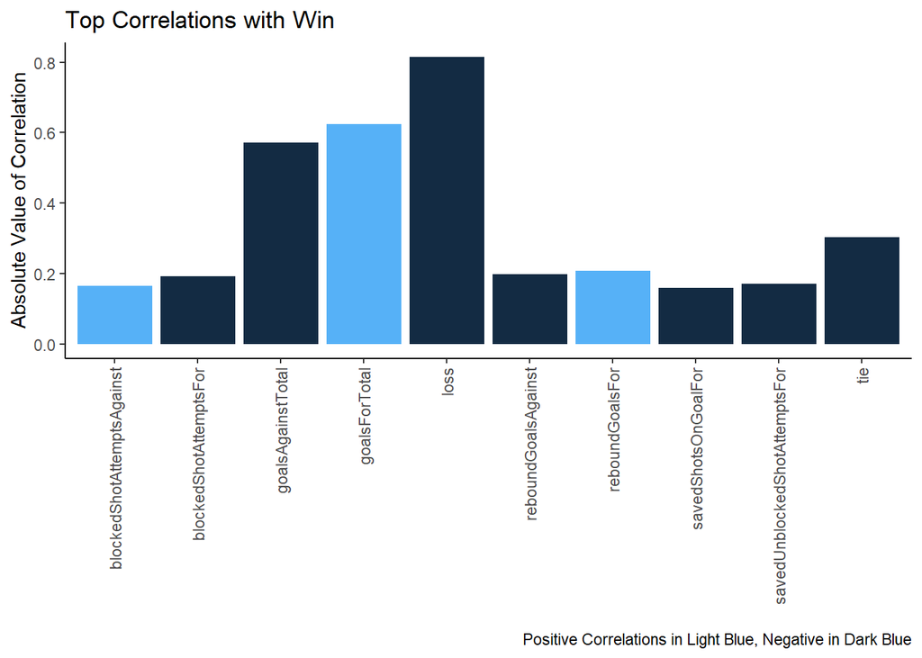

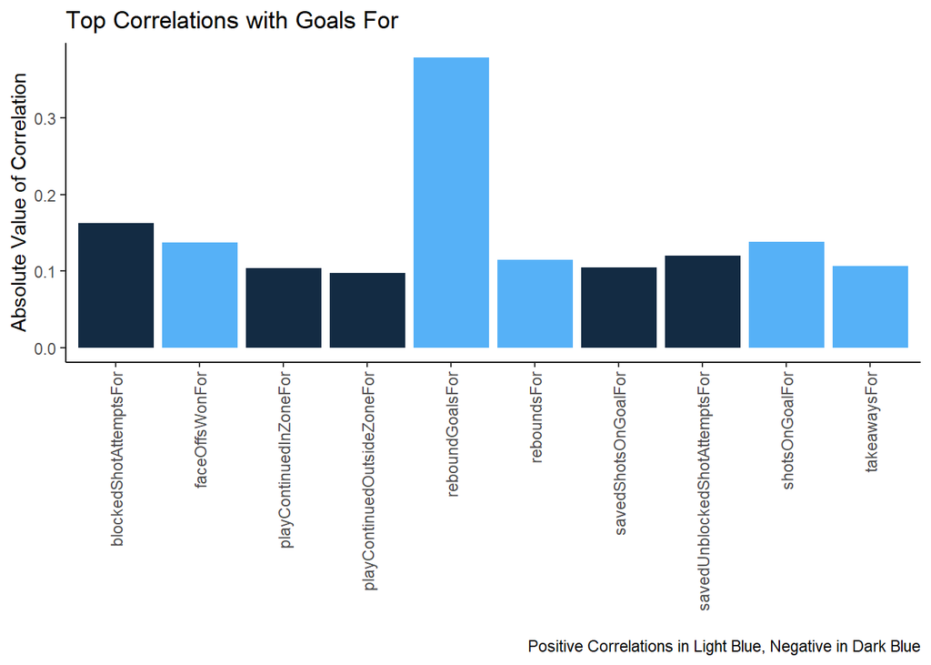

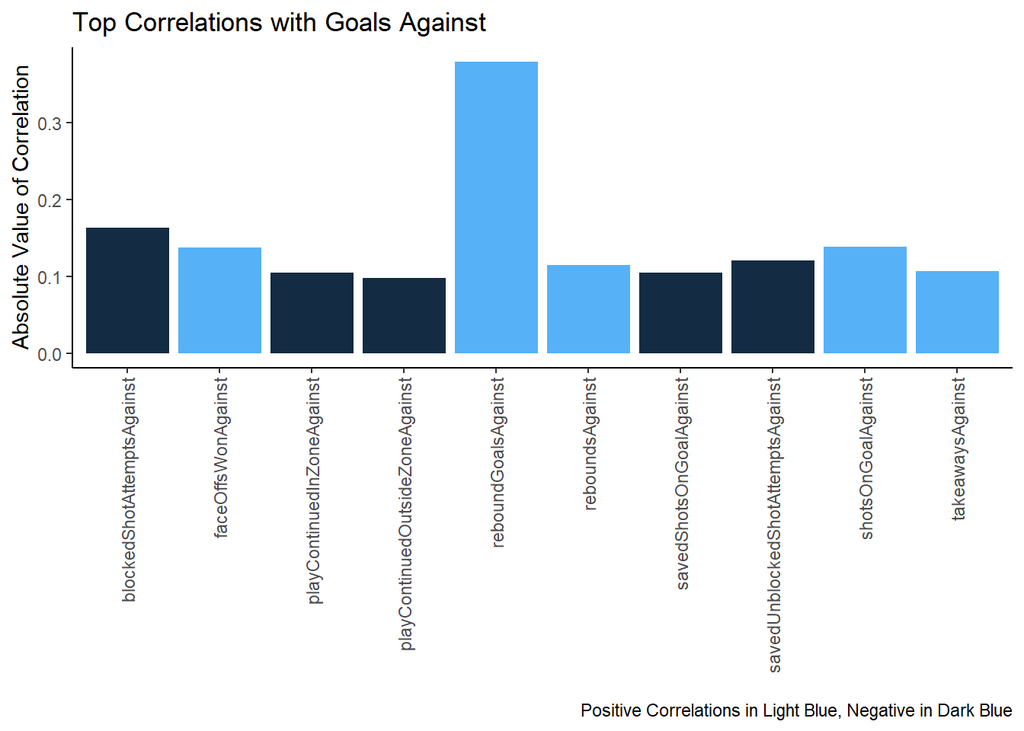

While it appears that wins are highly correlated with goals for and against (as we predicted), it seems much tougher to pin down a few specific predictors for goals for and against when you remove predictors that are types of goals (Rebound Goals For and Against). If our goal is to predict wins in a setting where we do not have the goals for or against for the game (halfway through the game or pregame), it may be prudent to build out models that predict goals for and against based on more fringe predictors that may have less variation through a season for a given team.

In order to find these models, it would be prudent to use shrinkage techniques like Lasso or Ridge regression in order to identify the predictors that those who are interested in predicting results of games should focus on. Once we have our expected goals for and against, it would then make sense to utilize some form of logistic regression to predict the result of the game as a classifier- however with logistic we would lose the capability of predicting a tie.

### Some Specific Variables to Study

How many goals a team scores differs depending on how often they have a Powerplay advantage. We can see the importance of Powerplays by looking at the variation in goals scored by teams in the sample.

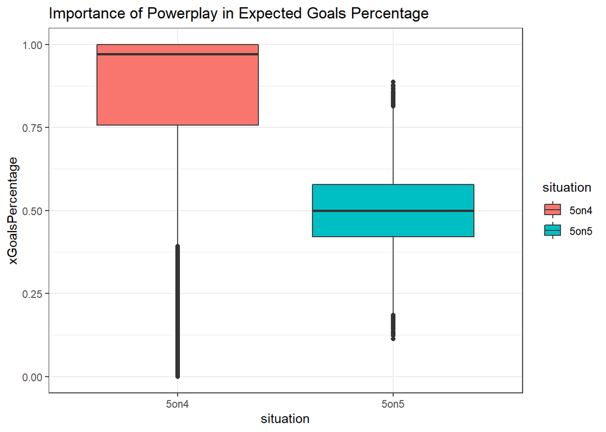

Obviously, teams are more likely to score on Powerplay, this is just showing the vast difference between the two situations. We could tie something together between penalty minutes and goals for the project.

Winning faceoffs also helps teams score goals and win games. We can look at the effect of winning faceoffs from the following plots:

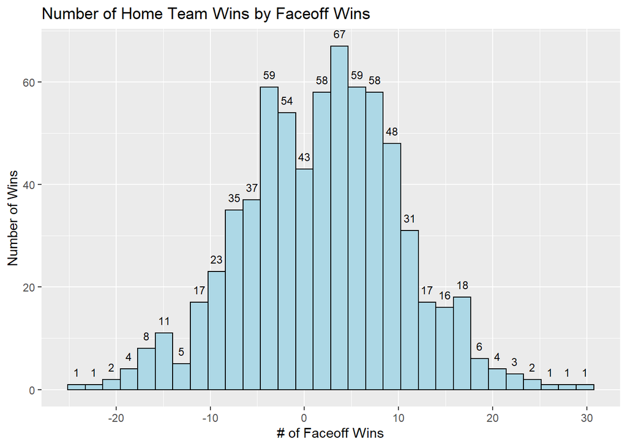

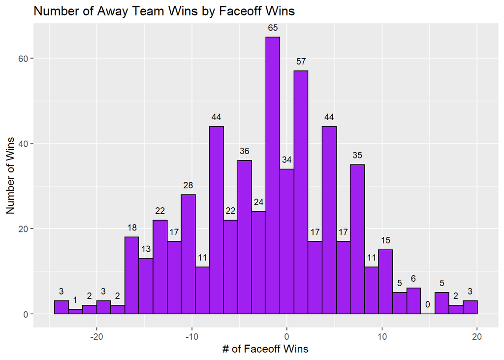

Finally, we can look at the effect of different types of shots on how many goals a team scores. Players take shots from many different places on the ice; not all these shots are equally likely to score a goal. Moneypuck separates shots into “Low Danger,” “Medium Danger,” and “High Danger,” giving us a way to see which shots are the best for scoring goals.

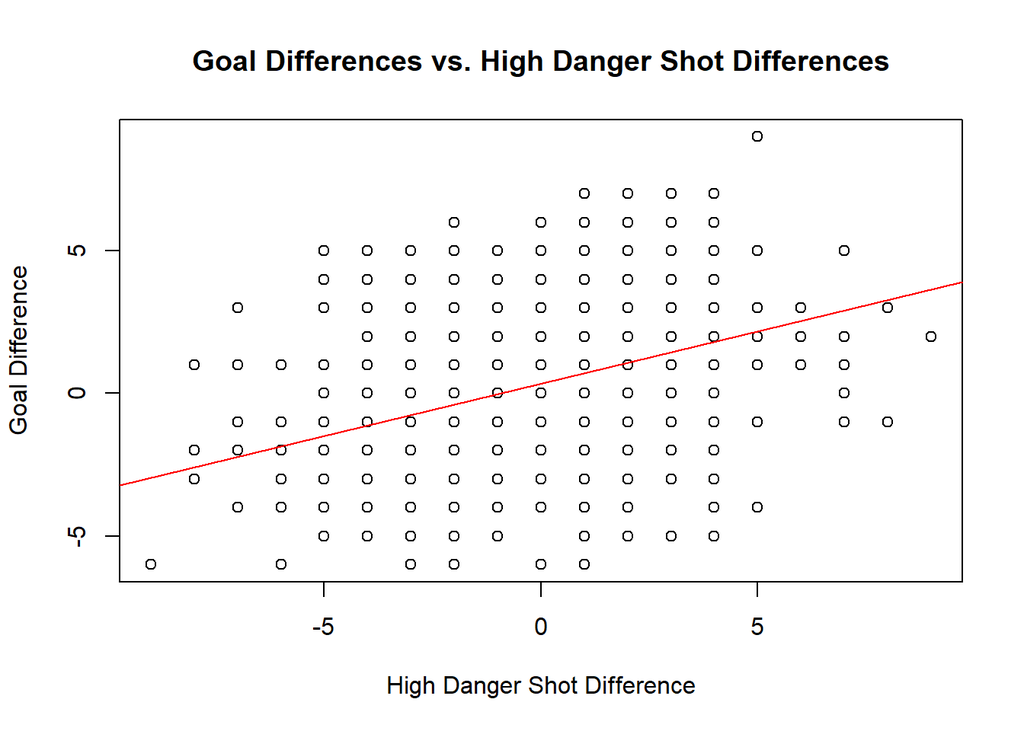

```
##    (Intercept) HighDangerDiff
##      0.3475596      0.3677729
```

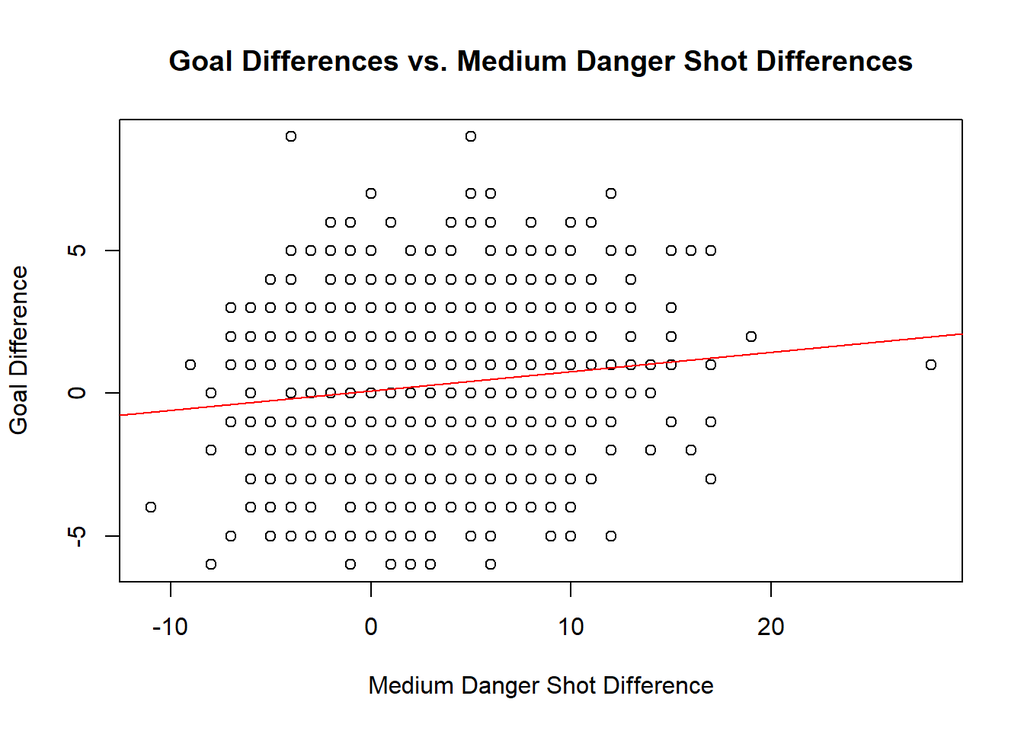

```
##      (Intercept) MediumDangerDiff
##       0.08360244       0.06773354
```

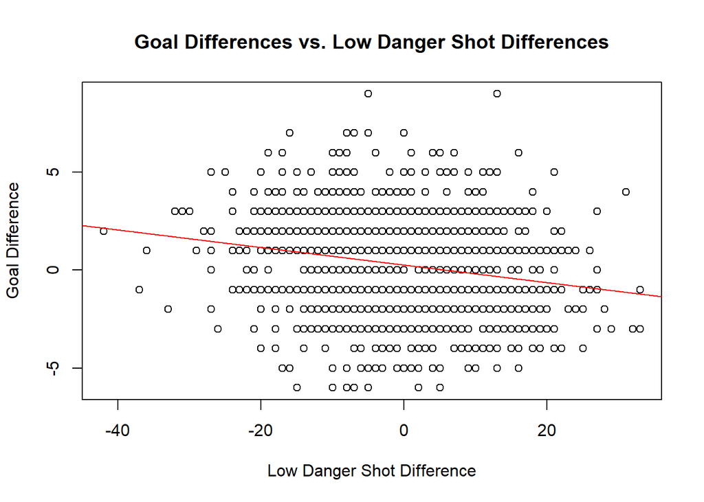

```
##   (Intercept) LowDangerDiff
##     0.2638481    -0.0450436
```

Teams with more high danger and medium danger shots tend to win, while teams with more low danger shots tend to lose.

Moneypuck also has special variables they calculate for each game: xGoalsFor and xGoalsAgainst. These represent the number of goals for and against a team would be “expected to have” based on a moneypuck’s model for predicting goals. To get a sense of the success of these variables in predicting wins and losses, we can plot the number of xGoalsFor and xGoalsAgainst for teams by whether they win or lose.

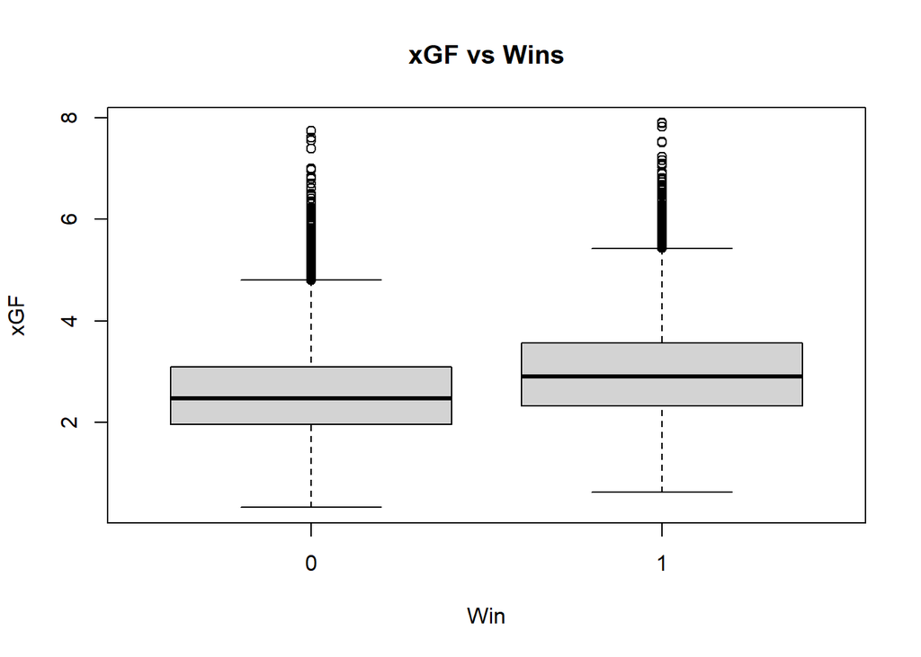

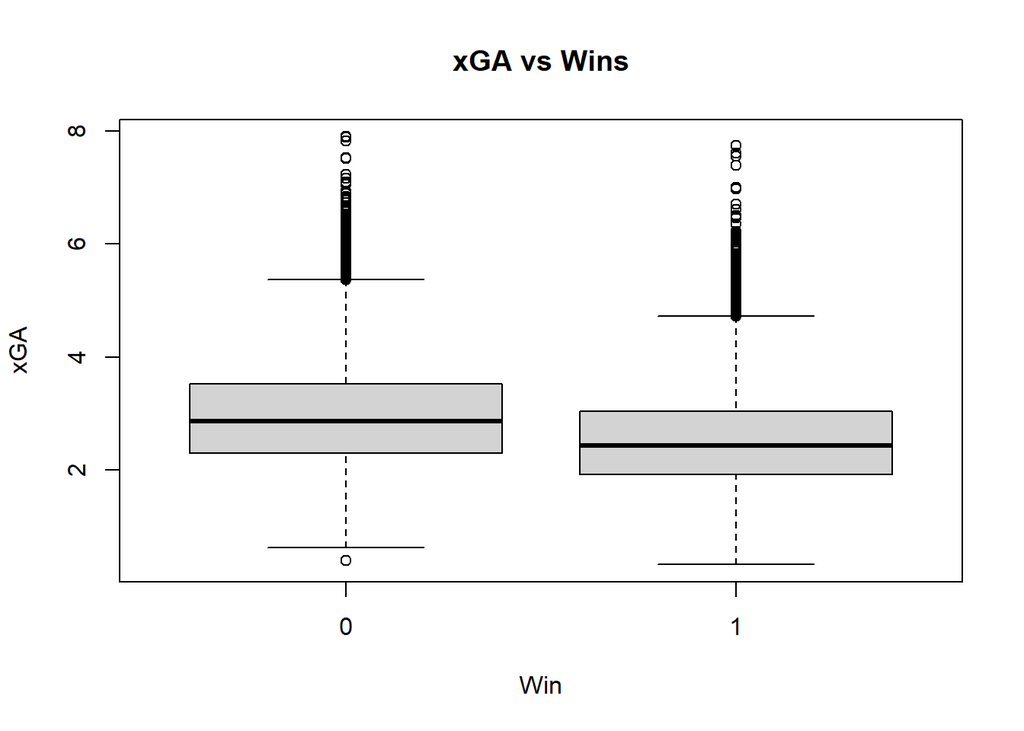

As we might think, teams that win games are expected to score more goals, whereas teams that lose games are expected to allow more goals against. Still, the difference doesn’t seem to be that great between winning and losing, so there are definitely other factors that determine whether a team wins or loses a given game.

## Early Attempts at ML Algorithms

We can get a sense for how we will build models later by looking at some basic LASSO and PCA techniques on the data we have. This might also tell us which variables are the most important when predicting goals and wins.

### LASSO (only home teams in 2017 season)

```
## 101 x 1 sparse Matrix of class "dgCMatrix"
##                                                    s1
## (Intercept)                               0.090829423
## xGoalsPercentage                          .
## corsiPercentage                           .
## fenwickPercentage                         .
## iceTime                                   .
## xOnGoalFor                                .
## xGoalsFor                                 .
## xReboundsFor                              .
## xFreezeFor                                .
## xPlayStoppedFor                           .
## xPlayContinuedInZoneFor                   .
## xPlayContinuedOutsideZoneFor              .
## flurryAdjustedxGoalsFor                   .
## scoreVenueAdjustedxGoalsFor               .
## flurryScoreVenueAdjustedxGoalsFor         .
## shotsOnGoalFor                            .
## missedShotsFor                            .
## blockedShotAttemptsFor                    .
## shotAttemptsFor                           .
## reboundsFor                               .
## reboundGoalsFor                           .
## freezeFor                                 .
## playStoppedFor                            .
## playContinuedInZoneFor                    .
## playContinuedOutsideZoneFor               .
## savedShotsOnGoalFor                       .
## savedUnblockedShotAttemptsFor             .
## penaltiesFor                              .
## penalityMinutesFor                        .
## faceOffsWonFor                            .
## hitsFor                                   .
## takeawaysFor                              .
## giveawaysFor                              .
## lowDangerShotsFor                         .
## mediumDangerShotsFor                      .
## highDangerShotsFor                        .
## lowDangerxGoalsFor                        .
## mediumDangerxGoalsFor                     .
```

[output cut: 48 more lines]

```
## highDangerxGoalsAgainst                   .
## lowDangerGoalsAgainst                     .
## mediumDangerGoalsAgainst                  .
## highDangerGoalsAgainst                    .
## scoreAdjustedShotsAttemptsAgainst         .
## unblockedShotAttemptsAgainst              .
## scoreAdjustedUnblockedShotAttemptsAgainst .
## dZoneGiveawaysAgainst                     .
## xGoalsFromxReboundsOfShotsAgainst         .
## xGoalsFromActualReboundsOfShotsAgainst    .
## reboundxGoalsAgainst                      .
## totalShotCreditAgainst                    .
## scoreAdjustedTotalShotCreditAgainst       .
## scoreFlurryAdjustedTotalShotCreditAgainst .
## win                                       0.008223115
```

```
## test error for lambda that minimizes cvm:  0.002743888
```

LASSO on goalsFor decreases the large number of predictors to just 4 predictors. We believe we could be more specific before performing LASSO during the project. After filetering and selecting within the data to be more specific, we could certainly perform LASSO on variables other than goalsFor as well.

### 2017 Home Team PCA

```
##                                               PC1          PC2          PC3
## xGoalsFor                             -0.19218398  0.133914433  0.016927184
## xReboundsFor                          -0.18864085 -0.026217394 -0.075363287
## xFreezeFor                            -0.19113718 -0.117547715  0.005469679
## xPlayStoppedFor                       -0.19786786 -0.045310894  0.020696858
## xPlayContinuedInZoneFor               -0.19221985 -0.092011266 -0.115041634
## xPlayContinuedOutsideZoneFor          -0.17481595 -0.109009478 -0.021147691
## flurryAdjustedxGoalsFor               -0.19155525  0.140565369  0.014779219
## scoreVenueAdjustedxGoalsFor           -0.19097944  0.141231513  0.025987679
## flurryScoreVenueAdjustedxGoalsFor     -0.19016917  0.148007065  0.024282755
## shotsOnGoalFor                        -0.17243851 -0.055136631 -0.046542660
## missedShotsFor                        -0.14860967 -0.062799629 -0.056326664
## blockedShotAttemptsFor                -0.09922618 -0.138489004  0.166964773
## shotAttemptsFor                       -0.18450679 -0.120544728  0.045110264
## goalsFor                              -0.03360669  0.291369044  0.111090851
## reboundsFor                           -0.11692900 -0.184875073  0.244288418
## reboundGoalsFor                       -0.03590119 -0.006271559 -0.085680935
## freezeFor                             -0.08360079  0.067582738  0.118588546
## playStoppedFor                        -0.03907852 -0.023834841 -0.364358315
## playContinuedInZoneFor                -0.18176532 -0.041531603 -0.070397037
## playContinuedOutsideZoneFor           -0.06159071 -0.225422935 -0.125207847
## savedShotsOnGoalFor                   -0.16762039 -0.117241512 -0.070556237
## savedUnblockedShotAttemptsFor         -0.19579174 -0.113212362 -0.078822223
## penaltiesFor                           0.03293498  0.085670415  0.270470395
## penalityMinutesFor                     0.01001130  0.045022347  0.267003088
## faceOffsWonFor                        -0.09656065  0.080446445  0.013762708
## hitsFor                               -0.04518274 -0.014482553  0.182244587
## takeawaysFor                          -0.13114207  0.041033127 -0.051767659
## giveawaysFor                          -0.06862405  0.165770645  0.184913526
## lowDangerShotsFor                     -0.15247299 -0.249489874 -0.044610304
## mediumDangerShotsFor                  -0.13540603  0.249654307 -0.154543775
## highDangerShotsFor                    -0.14981444 -0.009990832  0.291348046
## lowDangerxGoalsFor                    -0.16403697 -0.073509081 -0.169044461
## mediumDangerxGoalsFor                 -0.13605833  0.255458465 -0.132215404
## highDangerxGoalsFor                   -0.14065825  0.034788537  0.303189670
## lowDangerGoalsFor                      0.03235519 -0.071515056  0.102685322
## mediumDangerGoalsFor                  -0.04862629  0.370482000  0.037098981
## highDangerGoalsFor                    -0.03970520  0.165104708  0.070767228
## scoreAdjustedShotsAttemptsFor         -0.18532626 -0.095797215  0.056024803
## unblockedShotAttemptsFor              -0.20137917 -0.073246763 -0.063751397
```

[output cut: 41 more lines]

```
## mediumDangerxGoalsFor                 -0.0893164283
## highDangerxGoalsFor                    0.0561085026
## lowDangerGoalsFor                      0.0906587922
## mediumDangerGoalsFor                  -0.1408086278
## highDangerGoalsFor                     0.0784819170
## scoreAdjustedShotsAttemptsFor          0.0955812298
## unblockedShotAttemptsFor              -0.0505713832
## scoreAdjustedUnblockedShotAttemptsFor -0.0468692022
## dZoneGiveawaysFor                      0.1779016950
## xGoalsFromxReboundsOfShotsFor         -0.0150469521
## xGoalsFromActualReboundsOfShotsFor    -0.0552183978
## reboundxGoalsFor                      -0.0564679249
## totalShotCreditFor                     0.0116985363
## scoreAdjustedTotalShotCreditFor        0.0136813715
## scoreFlurryAdjustedTotalShotCreditFor  0.0166995853
```

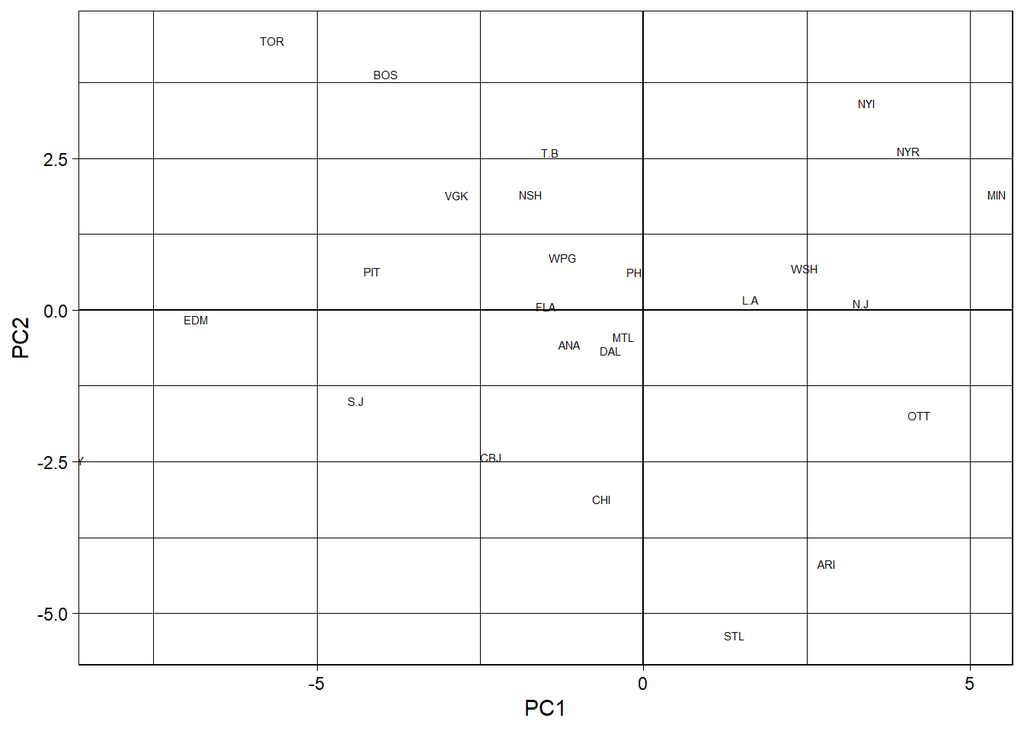

Similar to our homework with the NBA teams, this is just an idea of seeing how various teams performed at Home in the 2017 season. We could do PCA on specific variables that we think are important and/or could create a “Wins” column after grouping in our project.

# Proposal Part 5: ML Techniques

To predict goals for and against, we hope to develop a model using techniques like Ridge Regression, LASSO, and PCA. These techniques will allow us to idenfity which variables are most significant in predicting goals based on statistics we might find in a box score. From there, we hope to create a model using logistic regression, LDA, QDA, or KNN to predict whether a team will win, lose, or tie. We hope to be able to take data from a box score, or perhaps from a game still in progress, and predict which team is more likely to win. We could also use these techniques to determine how many games a team will win in a given season, to predict team success, or to provide a probability that a team will win a future game.